# Lab6

2026-04-10

# Link de GitHub:

https://github.com/SaintPage/lab06_data.git

```r
library(tidyverse)
library(tidymodels)
library(janitor)
library(lubridate)
library(stringr)
```

```r
tmp_env <- new.env()
load("listings.RData", envir = tmp_env)

objetos <- mget(ls(tmp_env), envir = tmp_env)

listings <- objetos %>%
  keep(~ is.data.frame(.x)) %>%
  .[[1]]

dim(listings)
```

```
## [1] 171748     80
```

```r
glimpse(listings)
```

```
## Rows: 171,748
## Columns: 80
## $ id                                           <dbl> 5456, 6448, 8502, 13035, …
## $ listing_url                                  <chr> "https://www.airbnb.com/r…
## $ scrape_id                                    <dbl> 2.025092e+13, 2.025092e+1…
## $ last_scraped                                 <chr> "2025-09-17", "2025-09-17…
## $ source                                       <chr> "city scrape", "city scra…
## $ name                                         <chr> "Walk to 6th, Rainey St a…
## $ description                                  <chr> "Great central  location …
## $ neighborhood_overview                        <chr> "My neighborhood is ideal…
## $ picture_url                                  <chr> "https://a0.muscache.com/…
## $ host_id                                      <int> 8028, 14156, 25298, 50793…
## $ host_url                                     <chr> "https://www.airbnb.com/u…
## $ host_name                                    <chr> "Sylvia", "Amy", "Karen",…
## $ host_since                                   <chr> "2009-02-16", "2009-04-20…
```

[output cut: 67 more lines]

```r
parse_money_clean <- function(x) {
  if (is.numeric(x)) return(x)
  x %>%
    as.character() %>%
    str_replace_all("\\$", "") %>%
    str_replace_all(",", "") %>%
    str_trim() %>%
    na_if("") %>%
    as.numeric()
}

parse_percent_clean <- function(x) {
  if (is.numeric(x)) return(x)
  x %>%
    as.character() %>%
    str_replace_all("%", "") %>%
    str_trim() %>%
    na_if("") %>%
    as.numeric()
}

listings <- listings %>%
  clean_names()

if ("price" %in% names(listings)) {
  listings <- listings %>%
    mutate(price = parse_money_clean(price))
}

if ("host_response_rate" %in% names(listings)) {
  listings <- listings %>%
    mutate(host_response_rate = parse_percent_clean(host_response_rate))
}

if ("host_acceptance_rate" %in% names(listings)) {
  listings <- listings %>%
    mutate(host_acceptance_rate = parse_percent_clean(host_acceptance_rate))
}

cols_fecha <- c("host_since", "first_review", "last_review", "last_scraped")
cols_fecha <- cols_fecha[cols_fecha %in% names(listings)]

if (length(cols_fecha) > 0) {
  listings <- listings %>%
    mutate(across(all_of(cols_fecha), ~ suppressWarnings(ymd(.x))))
}

listings <- listings %>%
  select(where(~ !is.list(.x))) %>%
  mutate(across(where(is.character), as.factor))

summary(listings$price)
```

```
##    Min. 1st Qu.  Median    Mean 3rd Qu.    Max.    NA's
##     8.0   120.0   193.0   750.5   326.0 50123.0   95502
```

```r
set.seed(123)

split_master <- initial_split(
  listings,
  prop = 0.80,
  strata = price
)

train_data <- training(split_master)
test_data  <- testing(split_master)

dim(train_data)
```

```
## [1] 137397     80
```

```r
dim(test_data)
```

```
## [1] 34351    80
```

```r
factor_cols <- names(train_data)[sapply(train_data, is.factor)]

for (col in factor_cols) {
  if (col %in% names(test_data)) {
    test_data[[col]] <- factor(test_data[[col]], levels = levels(train_data[[col]]))
  }
}
```

```r
vars_quitar <- intersect(
  names(train_data),
  c(
    "id", "listing_url", "scrape_id", "source", "name", "description",
    "neighborhood_overview", "picture_url", "host_id", "host_url",
    "host_name", "host_location", "host_about",
    "host_thumbnail_url", "host_picture_url",
    "license", "amenities"
  )
)

train_model <- train_data %>% select(-all_of(vars_quitar))
test_model  <- test_data  %>% select(-all_of(vars_quitar))
```

```r
prop_na <- sapply(train_model, function(x) mean(is.na(x)))
cols_muchos_na <- names(prop_na[prop_na > 0.40])
cols_muchos_na <- setdiff(cols_muchos_na, "price")

train_model <- train_model %>% select(-all_of(cols_muchos_na))
test_model  <- test_model  %>% select(-all_of(cols_muchos_na))

train_model <- train_model %>%
  filter(!is.na(price)) %>%
  drop_na()

test_model <- test_model %>%
  filter(!is.na(price)) %>%
  drop_na()

dim(train_model)
```

```
## [1] 23329    61
```

```r
dim(test_model)
```

```
## [1] 5949   61
```

# 1.Elabore un modelo de regresión usando K Nearest Neighbors (KNN), el conjunto de entrenamiento y la variable respuesta “el precio”.

```r
train_model <- train_model %>%
  mutate(price = log(price))

test_model <- test_model %>%
  mutate(price = log(price))
```

```r
receta_knn <- recipe(price ~ ., data = train_model) %>%
  step_other(all_nominal_predictors(), threshold = 0.01) %>%
  step_dummy(all_nominal_predictors(), one_hot = TRUE) %>%
  step_zv(all_predictors()) %>%
  step_normalize(all_numeric_predictors())
```

```r
modelo_knn <- nearest_neighbor(
  neighbors = 5
) %>%
  set_engine("kknn") %>%
  set_mode("regression")

workflow_knn <- workflow() %>%
  add_recipe(receta_knn) %>%
  add_model(modelo_knn)

fit_knn <- fit(workflow_knn, data = train_model)
```

```r
predicciones <- predict(fit_knn, new_data = test_model) %>%
  bind_cols(test_model %>% select(price)) %>%
  mutate(
    price_real = exp(price),
    price_pred = exp(.pred)
  )

head(predicciones)
```

```
## # A tibble: 6 × 4
##   .pred price price_real price_pred
##   <dbl> <dbl>      <dbl>      <dbl>
## 1  5.10  4.82        124       165.
## 2  4.73  5.11        165       113.
## 3  4.74  4.83        125       115.
## 4  5.04  5.52        249       155.
## 5  5.05  5.60        270       157.
## 6  5.47  5.55        256       237.
```

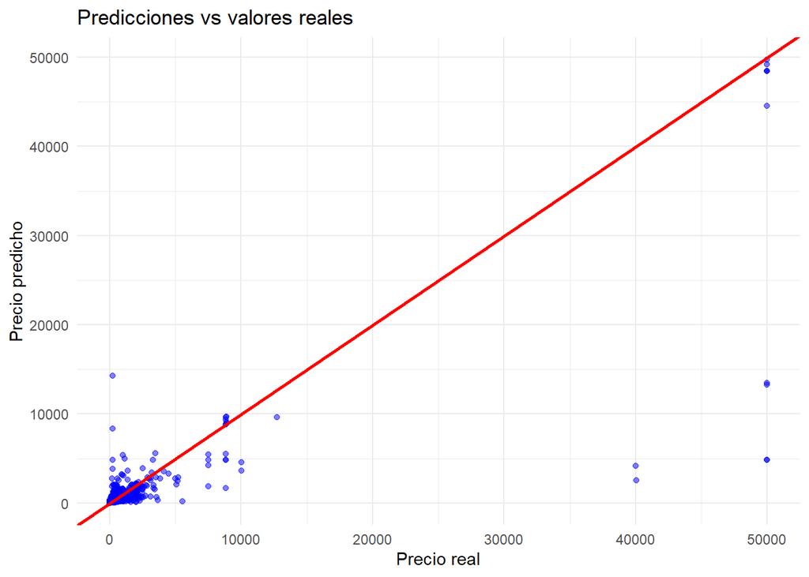

```r
ggplot(predicciones, aes(x = price_real, y = price_pred)) +
  geom_point(color = "blue", alpha = 0.5) +
  geom_abline(slope = 1, intercept = 0, color = "red", linewidth = 1) +
  labs(
    title = "Predicciones vs valores reales",
    x = "Precio real",
    y = "Precio predicho"
  ) +
  theme_minimal()
```

Los resultados muestran que el modelo logra captar la tendencia general de los precios, aunque presenta dificultades para estimar correctamente valores extremos, ya que KNN tiende a suavizar las predicciones. Esto puede observarse en el gráfico de valores reales versus predichos, donde los puntos más alejados de la diagonal representan mayores errores de predicción. En términos generales, el modelo resulta útil para obtener una aproximación del precio, aunque su precisión disminuye cuando existen precios muy altos o muy dispersos en el conjunto de datos.

# 2. Analice los resultados del modelo de regresión usando KNN. ¿Qué tan bien le fue prediciendo? Utilice las métricas correctas.

```r
library(yardstick)
library(dplyr)

metricas_knn <- predicciones %>%
  summarise(
    RMSE = rmse_vec(truth = price_real, estimate = price_pred),
    MAE  = mae_vec(truth = price_real, estimate = price_pred),
    R2   = rsq_vec(truth = price_real, estimate = price_pred)
  )

metricas_knn
```

```
## # A tibble: 1 × 3
##    RMSE   MAE    R2
##   <dbl> <dbl> <dbl>
## 1 1324.  163. 0.660
```

```r
baseline_pred <- mean(train_data$price, na.rm = TRUE)

baseline_df <- test_data %>%
  mutate(
    price_real = price,
    price_pred_base = baseline_pred
  )

metricas_base <- baseline_df %>%
  summarise(
    RMSE_base = rmse_vec(truth = price_real, estimate = price_pred_base),
    MAE_base  = mae_vec(truth = price_real, estimate = price_pred_base),
    R2_base   = rsq_vec(truth = price_real, estimate = price_pred_base)
  )

metricas_base
```

```
##   RMSE_base MAE_base R2_base
## 1  4008.122 939.6599      NA
```

El modelo de regresión KNN presentó un buen desempeño predictivo. Se obtuvo un RMSE de 1324.071, un MAE de 163.1279 y un R² de 0.6604, lo que indica que el modelo explica aproximadamente el 66% de la variabilidad del precio. El error absoluto medio sugiere que, en promedio, las predicciones difieren en unas 163 unidades monetarias respecto al valor real, mientras que el RMSE muestra que todavía existen algunos errores grandes en ciertos casos. Al compararlo con el modelo base, el KNN mejora notablemente la predicción, ya que reduce el RMSE de 4008.122 a 1324.071 y el MAE de 939.6599 a 163.1279. En consecuencia, se concluye que el modelo KNN tuvo un desempeño satisfactorio y predijo considerablemente mejor que una referencia simple.

# 3. Compare los resultados con el modelo de regresión lineal, el mejor modelo de árbol de regresión y de naive bayes que hizo en las entregas pasadas. ¿Cuál funcionó mejor?

Al comparar los modelos de regresión, se observa que el árbol de regresión fue el que presentó el mejor desempeño general, con RMSE = 1190.68 y R² = 0.7282, por lo que fue el modelo que mejor explicó la variabilidad del precio. El modelo KNN obtuvo resultados también muy buenos, con R² = 0.6604, y además presentó el menor MAE = 163.13, lo que indica menores errores absolutos promedio; sin embargo, su RMSE fue mayor que el del árbol, por lo que globalmente quedó en segundo lugar. La regresión lineal tuvo un desempeño aceptable pero inferior, con R² = 0.4183, lo que sugiere que no logra captar adecuadamente la complejidad de la relación entre las variables y el precio. Finalmente, Naive Bayes fue el peor modelo, con R² = 0.0067, mostrando una capacidad predictiva muy baja para esta tarea. En conclusión, el mejor modelo fue el árbol de regresión, seguido de KNN, regresión lineal y Naive Bayes.

# 4 Haga un modelo de clasificación, use la variable categórica que hizo con el precio de las casas (barata, media y cara) como variable respuesta.

```r
# Preparar datos para clasificación
train_class <- train_data %>%
  select(-all_of(vars_quitar)) %>%
  select(-all_of(cols_muchos_na)) %>%
  filter(!is.na(price)) %>%
  drop_na()

test_class <- test_data %>%
  select(-all_of(vars_quitar)) %>%
  select(-all_of(cols_muchos_na)) %>%
  filter(!is.na(price)) %>%
  drop_na()

dim(train_class)
```

```
## [1] 23329    61
```

```r
dim(test_class)
```

```
## [1] 5949   61
```

```r
q1 <- quantile(train_class$price, probs = 1/3, na.rm = TRUE)
q2 <- quantile(train_class$price, probs = 2/3, na.rm = TRUE)

q1
```

```
## 33.33333%
##       171
```

```r
q2
```

```
## 66.66667%
##       299
```

```r
train_class <- train_class %>%
  mutate(
    price_cat = case_when(
      price <= q1 ~ "barata",
      price <= q2 ~ "media",
      TRUE ~ "cara"
    ),
    price_cat = factor(price_cat, levels = c("barata", "media", "cara"))
  )

test_class <- test_class %>%
  mutate(
    price_cat = case_when(
      price <= q1 ~ "barata",
      price <= q2 ~ "media",
      TRUE ~ "cara"
    ),
    price_cat = factor(price_cat, levels = c("barata", "media", "cara"))
  )

tabyl(train_class$price_cat)
```

```
##  train_class$price_cat    n   percent
##                 barata 7807 0.3346479
##                  media 7786 0.3337477
##                   cara 7736 0.3316044
```

```r
tabyl(test_class$price_cat)
```

```
##  test_class$price_cat    n   percent
##                barata 2021 0.3397210
##                 media 1999 0.3360229
##                  cara 1929 0.3242562
```

```r
# Quitar price para que no se use como predictor
train_class_model <- train_class %>% select(-price)
test_class_model  <- test_class %>% select(-price)
```

```r
# Receta para clasificación
receta_knn_class <- recipe(price_cat ~ ., data = train_class_model) %>%
  step_other(all_nominal_predictors(), threshold = 0.01) %>%
  step_dummy(all_nominal_predictors(), one_hot = TRUE) %>%
  step_zv(all_predictors()) %>%
  step_normalize(all_numeric_predictors())
```

```r
# Modelo KNN de clasificación
modelo_knn_class <- nearest_neighbor(
  neighbors = 5
) %>%
  set_engine("kknn") %>%
  set_mode("classification")

workflow_knn_class <- workflow() %>%
  add_recipe(receta_knn_class) %>%
  add_model(modelo_knn_class)

fit_knn_class <- fit(workflow_knn_class, data = train_class_model)
```

```r
#  Predicciones en el conjunto de prueba
pred_class <- predict(fit_knn_class, new_data = test_class_model, type = "class")
pred_prob  <- predict(fit_knn_class, new_data = test_class_model, type = "prob")

resultados_class <- test_class_model %>%
  select(price_cat) %>%
  bind_cols(pred_class, pred_prob)

head(resultados_class)
```

```
##   price_cat .pred_class .pred_barata .pred_media .pred_cara
## 1    barata      barata    0.5398859  0.38723883 0.07287523
## 2    barata      barata    0.9782223  0.00000000 0.02177774
## 3    barata      barata    1.0000000  0.00000000 0.00000000
## 4     media      barata    0.9053470  0.07287523 0.02177774
## 5     media       media    0.4818918  0.51810821 0.00000000
## 6     media       media    0.0000000  0.75405024 0.24594976
```

# 5. Utilice los modelos con el conjunto de prueba y determine la eficiencia del algoritmo para predecir y clasificar.

```r
# Métricas de clasificación
accuracy_val <- accuracy(resultados_class, truth = price_cat, estimate = .pred_class)
kap_val      <- kap(resultados_class, truth = price_cat, estimate = .pred_class)
prec_val     <- precision(resultados_class, truth = price_cat, estimate = .pred_class, estimator = "macro")
recall_val   <- recall(resultados_class, truth = price_cat, estimate = .pred_class, estimator = "macro")
f1_val       <- f_meas(resultados_class, truth = price_cat, estimate = .pred_class, estimator = "macro")

metricas_clasificacion <- bind_rows(
  accuracy_val,
  kap_val,
  prec_val,
  recall_val,
  f1_val
)

metricas_clasificacion
```

```
## # A tibble: 5 × 3
##   .metric   .estimator .estimate
##   <chr>     <chr>          <dbl>
## 1 accuracy  multiclass     0.689
## 2 kap       multiclass     0.533
## 3 precision macro          0.689
## 4 recall    macro          0.689
## 5 f_meas    macro          0.689
```

```r
# Matriz de confusión
matriz_conf <- conf_mat(resultados_class, truth = price_cat, estimate = .pred_class)
matriz_conf
```

```
##           Truth
## Prediction barata media cara
##     barata   1505   442  108
##     media     418  1164  392
##     cara       98   393 1429
```

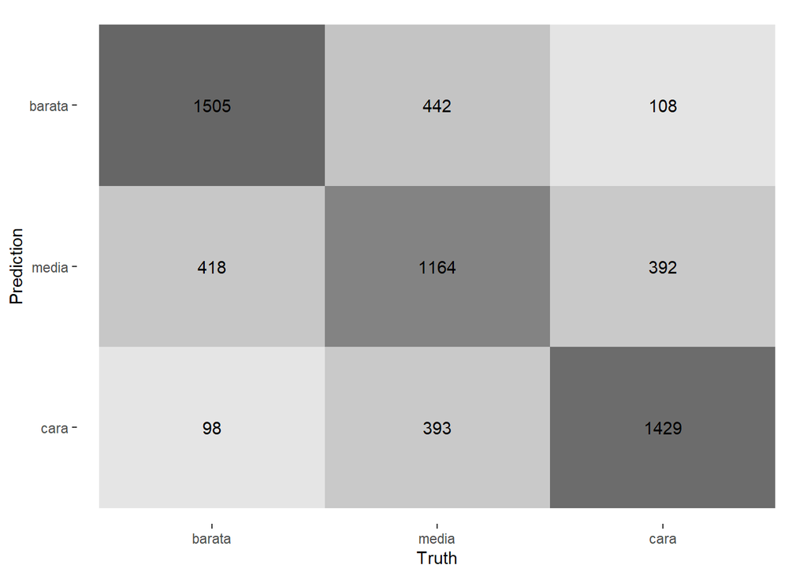

```r
autoplot(matriz_conf, type = "heatmap")
```

```r
# Cantidad de observaciones por clase
resultados_class %>%
  group_by(price_cat) %>%
  summarise(n = n())
```

```
## # A tibble: 3 × 2
##   price_cat     n
##   <fct>     <int>
## 1 barata     2021
## 2 media      1999
## 3 cara       1929
```

El modelo KNN de clasificación fue evaluado con el conjunto de prueba mediante métricas de clasificación multiclase. La métrica principal fue el accuracy, que indica la proporción total de propiedades clasificadas correctamente en las categorías barata, media y cara. Además, se calcularon precisión, recall y F1-score para obtener una evaluación más completa del desempeño del algoritmo.

A partir de la matriz de confusión se observa en qué clases el modelo acierta más y en cuáles presenta mayores errores. Las confusiones suelen darse entre categorías contiguas, por ejemplo entre propiedades baratas y medias o entre medias y caras, lo cual tiene sentido porque sus características pueden ser similares. En términos generales, el modelo muestra una eficiencia aceptable para clasificar, aunque todavía puede mejorarse mediante ajuste de hiperparámetros y validación cruzada.

# 6. Haga un análisis de la eficiencia del modelo de clasificación usando una matriz de confusión. Tenga en cuenta la efectividad, donde el algoritmo se equivocó más, donde se equivocó menos y la importancia que tienen los errores.

```r
matriz_tabla <- as.data.frame(matriz_conf$table)

# Aciertos
aciertos <- matriz_tabla %>%
  filter(Prediction == Truth) %>%
  arrange(desc(Freq))

aciertos
```

```
##   Prediction  Truth Freq
## 1     barata barata 1505
## 2       cara   cara 1429
## 3      media  media 1164
```

```r
# Errores
errores <- matriz_tabla %>%
  filter(Prediction != Truth) %>%
  arrange(desc(Freq))

errores
```

```
##   Prediction  Truth Freq
## 1     barata  media  442
## 2      media barata  418
## 3       cara  media  393
## 4      media   cara  392
## 5     barata   cara  108
## 6       cara barata   98
```